# From reads to variants: human data

**Purpose.** Take raw sequencing reads all the way to called variants, so that the file formats stop being black boxes. Every later exercise starts from one of the files you make here.

**What you will do**

- look at a FASTQ file and run FastQC on it
- map the reads to a reference with `bwa mem`
- convert, sort and index the alignment (SAM -> BAM)
- inspect the alignment with `samtools tview` and `mpileup`, and look at the depth
- call variants with `bcftools` and read the VCF

**The data.** **NA19238**, one individual from the **1000 Genomes Project**, population **YRI** (Yoruba in Ibadan, Nigeria). Paired-end Illumina reads from **chromosome 21**, 171,880 read pairs of 100 bp, sequenced at low depth. The reference is human chromosome 21 only (46.9 Mb), so that mapping finishes in about a minute.

- File formats (FASTQ, SAM/BAM, VCF)
- Mapping (single-end, paired-end) NGS data to a reference sequence
- Read flags
- VERY IMPORTANT, you need to identify the 'pipe' button on your computer '|'.

## Environment setup

```
#############################################################
# ALL PATHS ARE SET HERE
# If the data or the software moves, this is the ONLY cell you
# need to change. No cell below this one uses a full path.
#############################################################

# where the shared data and software live
DATA=/course/data/current_data/NGSintro/human
SOFTWARE=/course/data/current_data/NGSintro/software

# where you will do the exercise
WORK_DIR=$HOME/ngs_intro_human

# input files
NA19238_1_FQ=$DATA/NA19238.YRI.low_coverage.chr21_1.fq.gz
NA19238_2_FQ=$DATA/NA19238.YRI.low_coverage.chr21_2.fq.gz
CHR21=$DATA/chr21.fa.gz

# programs
PICARD=$SOFTWARE/picard.jar
FASTQC=fastqc

# the same files as they are named inside WORK_DIR, and the sample name
# used for every file you create below
FQ1=$(basename $NA19238_1_FQ)
FQ2=$(basename $NA19238_2_FQ)
REF=$(basename $CHR21)
SAMPLE=NA19238

# the chromosome in the reduced reference
CHROM=chr21

# make WORK_DIR readable by the R and python cells further down
mkdir -p $WORK_DIR
echo $WORK_DIR > $HOME/.ngs_intro_human_workdir

echo --programs that are installed:--
which samtools
which bwa
which angsd
which bcftools
which $FASTQC
ls $PICARD

echo --Datasets that will be used--
echo pair of fastQ files
ls $NA19238_1_FQ
ls $NA19238_2_FQ

echo reference genome
ls $CHR21
```

First make a folder for the exercise and add symbolic links to the reference genomes and the fastQ files

```
# enter the folder that was created in the first cell
cd $WORK_DIR

#make links to files and add them to the folder
cp -sf  $NA19238_1_FQ .
cp -sf  $NA19238_2_FQ .
cp -sf  ${CHR21}* .

echo --- files in folder ---
ls
```

```
--- files in folder ---
chr21.fa.gz	 chr21.fa.gz.fai  NA19238.YRI.low_coverage.chr21_1.fq.gz
chr21.fa.gz.amb  chr21.fa.gz.gzi  NA19238.YRI.low_coverage.chr21_2.fq.gz
chr21.fa.gz.ann  chr21.fa.gz.pac
chr21.fa.gz.bwt  chr21.fa.gz.sa
```

```
# set up R working space
# the working directory was set in the first cell of the notebook
work_d <- readLines(path.expand("~/.ngs_intro_human_workdir"))[1]
setwd(work_d)
getwd()
```

'/davidData/data/course/.nbrender_home/ngs_intro_human'

```
# set up python working space
# the working directory was set in the first cell of the notebook
import os
work_d = open(os.path.expanduser("~/.ngs_intro_human_workdir")).read().strip()
os.chdir(work_d)
print(os.getcwd())
```

```
/davidData/data/course/.nbrender_home/ngs_intro_human
```

## Mapping one reduced genome

[figure not shown]

In this exercise you will align a fastq file using bwa and generate a SAM file.

The fastQ file NA19238.YRI.low_coverage.chr21_1.fq.gz has variable name with *_1.fq.gz, which is the first read of the read pair.

Before we start mapping we want to perform some QC of the data.

# Step 1: FastQ file and QC

[figure not shown]

### Viewing the input files

View the fastq file (NA19238.YRI.low_coverage.chr21_1.fq.gz) using the head command and identify the reads and quality scores (ignore the Broken pipe warning).

```
# -n determines the number of lines printed
gunzip -c $FQ1 | head -n 12
```

```
@SRR794309.186
CCTTTTTATGGCTGAGTAGTATTCCACAGTTTCTTTACCCACTCCTTGATCAATAGGCACTTGGGTTGGTTCCACGATTTTGCATTTGTGAATTGTGTTG
+
CCCFFFFFHHHHHJJJFHIFHHJIJJJJJHIJJJJJIIJJJJJJJJJIHIIJJJJJJJJJJJJJJFHIJHFHHHHFFFDDEEEEEEDEACCEEECDCCDD
@SRR794309.852
TCCTTCCCCACTAACCCTCTACCTGCTTCTACAATGCATTCTGAATAGATGTTGCCAGGAGGAATAATTCTGGCAAATTAATAAGGCTTGTCATGCAAAA
+
CCCFFFFFHHHHHJJJJJJJIJJJJJJJJIJJJJIJJJJJIIIIJJJIIIHGIIJJGJJJJJGIIIJGIIIJIGHEHHFFFFFFECDEEDDDEEDDCCDD
@SRR794309.869
TACATCGTGAAGAAGTTTCTCAGAATGCTTCTGTGTAGTTCTTATTTGAAGATATTTGGTTTTCCACTGTAGGCCTCAAAGCGCTCCAAATATCCACTTG
+
CCCFFFFFHHHHGJJIJIIJJJJJJJJJIJJJJGIFIIHIJJJJJJJGIIJJIJJJJJJGGIJJIJJJJIIJJIHIHIGIHHHFFFDDEEEEFFEDDDDC

gzip: stdout: Broken pipe
```

Identify the read names, the sequence, the separator line, and the base quality scores in the FASTQ output above. Fill in the ???? below for one complete read.

```
?????        @read_name
?????        ACTG...
?????        +
?????        quality_scores
```

**Questions**

- Each read takes up four lines. Which line holds the bases, and which holds their quality scores?
- The sequence line and the quality line are the same length. Why must that be true?

### Run the cell below to take the quiz

```
# run to start quiz
from jupyterquiz import display_quiz
display_quiz('https://raw.githubusercontent.com/popgenDK/courses/main/current_exercises/ngs/quiz/fastq_format.json')
```

The below command count the number of lines in the file

- How many lines do you have ????
- How many Reads in the data ????
- is the number of lines the same in the 2 fastQ files ???? ( modify the code below to see the number of lines in the other file)

```
gunzip -c $FQ2 |  wc -l
```

```
687520
```

- How many lines do you have?
- How many reads are in the data? (there are four lines per read)
- Is the number of lines the same in the two FASTQ files?

### Run the cell below to take the quiz

```
# run to start quiz
from jupyterquiz import display_quiz
display_quiz('https://raw.githubusercontent.com/popgenDK/courses/main/current_exercises/ngs/quiz/fastq_counts_human.json')
```

View the reference fasta file (chr21.fa.gz) using the head command. The first many bases of the reference genome is all Ns ( unknown bases). First view the first bases of chr21 then try to view other parts. You can modify the below uncommented code below

```
# first 20 lines
gunzip -c $REF | head -n 20

# view another part of the reference (uncomment and modify below)
# gunzip -c $REF | head -n 200 | tail -n 20
```

```
>chr21
NNNNNNNNNNNNNNNNNNNNNNNNNNNNNNNNNNNNNNNNNNNNNNNNNN
NNNNNNNNNNNNNNNNNNNNNNNNNNNNNNNNNNNNNNNNNNNNNNNNNN
NNNNNNNNNNNNNNNNNNNNNNNNNNNNNNNNNNNNNNNNNNNNNNNNNN
NNNNNNNNNNNNNNNNNNNNNNNNNNNNNNNNNNNNNNNNNNNNNNNNNN
NNNNNNNNNNNNNNNNNNNNNNNNNNNNNNNNNNNNNNNNNNNNNNNNNN
NNNNNNNNNNNNNNNNNNNNNNNNNNNNNNNNNNNNNNNNNNNNNNNNNN
NNNNNNNNNNNNNNNNNNNNNNNNNNNNNNNNNNNNNNNNNNNNNNNNNN
NNNNNNNNNNNNNNNNNNNNNNNNNNNNNNNNNNNNNNNNNNNNNNNNNN
NNNNNNNNNNNNNNNNNNNNNNNNNNNNNNNNNNNNNNNNNNNNNNNNNN
NNNNNNNNNNNNNNNNNNNNNNNNNNNNNNNNNNNNNNNNNNNNNNNNNN
NNNNNNNNNNNNNNNNNNNNNNNNNNNNNNNNNNNNNNNNNNNNNNNNNN
NNNNNNNNNNNNNNNNNNNNNNNNNNNNNNNNNNNNNNNNNNNNNNNNNN
NNNNNNNNNNNNNNNNNNNNNNNNNNNNNNNNNNNNNNNNNNNNNNNNNN
NNNNNNNNNNNNNNNNNNNNNNNNNNNNNNNNNNNNNNNNNNNNNNNNNN
NNNNNNNNNNNNNNNNNNNNNNNNNNNNNNNNNNNNNNNNNNNNNNNNNN
NNNNNNNNNNNNNNNNNNNNNNNNNNNNNNNNNNNNNNNNNNNNNNNNNN
NNNNNNNNNNNNNNNNNNNNNNNNNNNNNNNNNNNNNNNNNNNNNNNNNN
NNNNNNNNNNNNNNNNNNNNNNNNNNNNNNNNNNNNNNNNNNNNNNNNNN
NNNNNNNNNNNNNNNNNNNNNNNNNNNNNNNNNNNNNNNNNNNNNNNNNN

gzip: stdout: Broken pipe
```

**Questions**

- The first line starts with `>`. What does that line tell you?
- Why are there long stretches of `N` at the start of chromosome 21?
- A FASTA file has no quality scores, while a FASTQ file does. Why does the reference not need them?

# step 1: FastQ file and QC

[figure not shown]

#### FastQC

Let's see if there are any issues with the sequencing reads.

```
$FASTQC --nogroup $FQ1

echo ---- fastQC has created this file ----
ls *html
```

```
Started analysis of NA19238.YRI.low_coverage.chr21_1.fq.gz
Approx 5% complete for NA19238.YRI.low_coverage.chr21_1.fq.gz
Approx 10% complete for NA19238.YRI.low_coverage.chr21_1.fq.gz
Approx 15% complete for NA19238.YRI.low_coverage.chr21_1.fq.gz
Approx 20% complete for NA19238.YRI.low_coverage.chr21_1.fq.gz
Approx 25% complete for NA19238.YRI.low_coverage.chr21_1.fq.gz
Approx 30% complete for NA19238.YRI.low_coverage.chr21_1.fq.gz
Approx 35% complete for NA19238.YRI.low_coverage.chr21_1.fq.gz
Approx 40% complete for NA19238.YRI.low_coverage.chr21_1.fq.gz
Approx 45% complete for NA19238.YRI.low_coverage.chr21_1.fq.gz
Approx 50% complete for NA19238.YRI.low_coverage.chr21_1.fq.gz
Approx 55% complete for NA19238.YRI.low_coverage.chr21_1.fq.gz
Approx 60% complete for NA19238.YRI.low_coverage.chr21_1.fq.gz
Approx 65% complete for NA19238.YRI.low_coverage.chr21_1.fq.gz
Approx 70% complete for NA19238.YRI.low_coverage.chr21_1.fq.gz
Approx 75% complete for NA19238.YRI.low_coverage.chr21_1.fq.gz
Approx 80% complete for NA19238.YRI.low_coverage.chr21_1.fq.gz
Approx 85% complete for NA19238.YRI.low_coverage.chr21_1.fq.gz
Approx 90% complete for NA19238.YRI.low_coverage.chr21_1.fq.gz
Approx 95% complete for NA19238.YRI.low_coverage.chr21_1.fq.gz
Analysis complete for NA19238.YRI.low_coverage.chr21_1.fq.gz
---- fastQC has created this file ----
NA19238.YRI.low_coverage.chr21_1_fastqc.html
```

To view the report, switch to the main browser tab for the Jupyter notebook. Enter the exercise folder and find the html file. Click on the file to open the FastQC report.

It will look something like the picture below.

[figure not shown]

**Questions**

- How long are the reads?
- Does the base quality drop towards the end of the reads? Why does that happen with Illumina sequencing?
- Did any module fail or raise a warning?

### Run the cell below to take the quiz

```
# run to start quiz
from jupyterquiz import display_quiz
display_quiz('https://raw.githubusercontent.com/popgenDK/courses/main/current_exercises/ngs/quiz/fastqc_human.json')
```

## Aligning

[figure not shown]

- Mapping to a reference genome
- What is in the sam/bam file?
- Quality: Mapping vs Alignment
- Sequencing Depth

Align the reads using bwa. We use bwa in the exercises because it is fast and widely used. We first need to index the reference chromosome, followed by the actual aligning process. If should take around 1 min to finish.

```
## # we will use the prepared index files
# bwa index $REF
```

The index is already built here, so the command is commented out. Building it on a full human genome takes well over an hour.

**Question**

- Why does bwa need an index of the reference before it can map anything?

Once the index is made, the second step is to map the reads. There are several ways to do this, but I suggest you use the bwa mem mode, which is the most commonly used these days. Again you can run it with no arguments to get info about how to use it.

```
# see options
bwa mem
```

```
Usage: bwa mem [options] <idxbase> <in1.fq> [in2.fq]

Algorithm options:

       -t INT        number of threads [1]
       -k INT        minimum seed length [19]
       -w INT        band width for banded alignment [100]
       -d INT        off-diagonal X-dropoff [100]
       -r FLOAT      look for internal seeds inside a seed longer than {-k} * FLOAT [1.5]
       -y INT        seed occurrence for the 3rd round seeding [20]
       -c INT        skip seeds with more than INT occurrences [500]
       -D FLOAT      drop chains shorter than FLOAT fraction of the longest overlapping chain [0.50]
       -W INT        discard a chain if seeded bases shorter than INT [0]
       -m INT        perform at most INT rounds of mate rescues for each read [50]
       -S            skip mate rescue
       -P            skip pairing; mate rescue performed unless -S also in use

Scoring options:

       -A INT        score for a sequence match, which scales options -TdBOELU unless overridden [1]
       -B INT        penalty for a mismatch [4]
       -O INT[,INT]  gap open penalties for deletions and insertions [6,6]
       -E INT[,INT]  gap extension penalty; a gap of size k cost '{-O} + {-E}*k' [1,1]
       -L INT[,INT]  penalty for 5'- and 3'-end clipping [5,5]
       -U INT        penalty for an unpaired read pair [17]

       -x STR        read type. Setting -x changes multiple parameters unless overridden [null]
                     pacbio: -k17 -W40 -r10 -A1 -B1 -O1 -E1 -L0  (PacBio reads to ref)
                     ont2d: -k14 -W20 -r10 -A1 -B1 -O1 -E1 -L0  (Oxford Nanopore 2D-reads to ref)
                     intractg: -B9 -O16 -L5  (intra-species contigs to ref)

Input/output options:

       -p            smart pairing (ignoring in2.fq)
       -R STR        read group header line such as '@RG\tID:foo\tSM:bar' [null]
       -H STR/FILE   insert STR to header if it starts with @; or insert lines in FILE [null]
       -o FILE       sam file to output results to [stdout]
       -j            treat ALT contigs as part of the primary assembly (i.e. ignore <idxbase>.alt file)
       -5            for split alignment, take the alignment with the smallest coordinate as primary
       -q            don't modify mapQ of supplementary alignments
       -K INT        process INT input bases in each batch regardless of nThreads (for reproducibility) []

       -v INT        verbosity level: 1=error, 2=warning, 3=message, 4+=debugging [3]
       -T INT        minimum score to output [30]
       -h INT[,INT]  if there are <INT hits with score >80% of the max score, output all in XA [5,200]
       -a            output all alignments for SE or unpaired PE
       -C            append FASTA/FASTQ comment to SAM output
       -V            output the reference FASTA header in the XR tag
       -Y            use soft clipping for supplementary alignments
       -M            mark shorter split hits as secondary

       -I FLOAT[,FLOAT[,INT[,INT]]]
                     specify the mean, standard deviation (10% of the mean if absent), max
                     (4 sigma from the mean if absent) and min of the insert size distribution.
                     FR orientation only. [inferred]

Note: Please read the man page for detailed description of the command line and options.
```

**Questions**

- Which option sets the number of threads?
- Which three inputs does `bwa mem` need in order to map paired-end data?

The number of options may be a bit overwhelming, but you can run it with no additional options, although I suggest you add "-t 5" to run 5 threads if your computer has multiple cores. It reads the compressed fastq files directly, so you need not decompress them. By default the result comes on stdout (in the terminal), so you have to redirect to a file, like the below command. We also want to add a read group name with information about where the reads comes from. This is very useful if you have sequencing data from multiple libraries.  
Now try to align the data

```
#align the data ( take ~ 1 min)
bwa mem -R '@RG\tID:foo\tSM:bar\tLB:library1' -t 5 $REF $FQ1 $FQ2  > $SAMPLE.sam
```

```
[M::bwa_idx_load_from_disk] read 0 ALT contigs
[M::process] read 343760 sequences (34376000 bp)...
[M::mem_pestat] # candidate unique pairs for (FF, FR, RF, RR): (12, 93011, 73, 12)
[M::mem_pestat] analyzing insert size distribution for orientation FF...
[M::mem_pestat] (25, 50, 75) percentile: (548, 1375, 6799)
[M::mem_pestat] low and high boundaries for computing mean and std.dev: (1, 19301)
[M::mem_pestat] mean and std.dev: (2500.67, 3111.22)
[M::mem_pestat] low and high boundaries for proper pairs: (1, 25552)
[M::mem_pestat] analyzing insert size distribution for orientation FR...
[M::mem_pestat] (25, 50, 75) percentile: (134, 170, 222)
[M::mem_pestat] low and high boundaries for computing mean and std.dev: (1, 398)
[M::mem_pestat] mean and std.dev: (181.60, 65.41)
[M::mem_pestat] low and high boundaries for proper pairs: (1, 486)
[M::mem_pestat] analyzing insert size distribution for orientation RF...
[M::mem_pestat] (25, 50, 75) percentile: (559, 1777, 4330)
[M::mem_pestat] low and high boundaries for computing mean and std.dev: (1, 11872)
[M::mem_pestat] mean and std.dev: (2573.14, 2464.51)
[M::mem_pestat] low and high boundaries for proper pairs: (1, 15643)
[M::mem_pestat] analyzing insert size distribution for orientation RR...
[M::mem_pestat] (25, 50, 75) percentile: (489, 1007, 1830)
[M::mem_pestat] low and high boundaries for computing mean and std.dev: (1, 4512)
[M::mem_pestat] mean and std.dev: (920.10, 479.40)
[M::mem_pestat] low and high boundaries for proper pairs: (1, 5853)
[M::mem_pestat] skip orientation FF
[M::mem_pestat] skip orientation RF
[M::mem_pestat] skip orientation RR
[M::mem_process_seqs] Processed 343760 reads in 79.477 CPU sec, 15.953 real sec
[main] Version: 0.7.17-r1188
[main] CMD: bwa mem -R @RG\tID:foo\tSM:bar\tLB:library1 -t 5 chr21.fa.gz NA19238.YRI.low_coverage.chr21_1.fq.gz NA19238.YRI.low_coverage.chr21_2.fq.gz
[main] Real time: 16.999 sec; CPU: 80.522 sec
```

**Questions**

- The output was sent to a file with `>`. What would have happened without it?
- `-R '@RG\tID:foo\tSM:bar\tLB:library1'` adds a read group. Why does it matter to record which sample a read came from, once you analyse many individuals together?

Let's look at the generated sam file

```
# view first 20 lines
head -n20 $SAMPLE.sam
```

```
@SQ	SN:chr21	LN:46944323
@RG	ID:foo	SM:bar	LB:library1
@PG	ID:bwa	PN:bwa	VN:0.7.17-r1188	CL:bwa mem -R @RG\tID:foo\tSM:bar\tLB:library1 -t 5 chr21.fa.gz NA19238.YRI.low_coverage.chr21_1.fq.gz NA19238.YRI.low_coverage.chr21_2.fq.gz
SRR794309.186	99	chr21	16239093	60	100M	=	16239300	307	CCTTTTTATGGCTGAGTAGTATTCCACAGTTTCTTTACCCACTCCTTGATCAATAGGCACTTGGGTTGGTTCCACGATTTTGCATTTGTGAATTGTGTTG	CCCFFFFFHHHHHJJJFHIFHHJIJJJJJHIJJJJJIIJJJJJJJJJIHIIJJJJJJJJJJJJJJFHIJHFHHHHFFFDDEEEEEEDEACCEEECDCCDD	NM:i:0	MD:Z:100	MC:Z:100M	AS:i:100	XS:i:26	…
SRR794309.186	147	chr21	16239300	60	100M	=	16239093	-307	TCTTTAAGAAATCTCCACACTGTTTTCTGTGGTGGCTATACTAGCTTACAATCCCACCAGCAGTGTAGAAGTGTTCCCTCATCACTGCACCCACGCCAAC	DDDEDDEDDDDDDDDCACCDDDDDDDEDDDFFFFFHHEEEHHJJJJIGIHJGJIHFJJJJJJJJJJJJJJJJIJIJJIHJJIHEJIIHFHHHDFFFFCCC	NM:i:0	MD:Z:100	MC:Z:100M	AS:i:100	XS:i:3…
SRR794309.852	83	chr21	18423539	60	100M	=	18423474	-165	TTTTGCATGACAAGCCTTATTAATTTGCCAGAATTATTCCTCCTGGCAACATCTATTCAGAATGCATTGTAGAAGCAGGTAGAGGGTTAGTGGGGAAGGA	DDCCDDEEDDDEEDCEFFFFFFHHEHGIJIIIGJIIIGJJJJJGJJIIGHIIIJJJIIIIJJJJJIJJJJIJJJJJJJJIJJJJJJJHHHHHFFFFFCCC	NM:i:0	MD:Z:100	MC:Z:100M	AS:i:100	XS:i:0	…
SRR794309.852	163	chr21	18423474	60	100M	=	18423539	165	ATTTACCATTACTTTGTGGGATTGCTTTTGGTTTATTGTCCTGTTATTCTGATACTGAATTGATATTTTGCATGACAAGCCTTATTAATTTGCCAGAATT	CCCFFFFFHHHHHJJJGIJJIJJJJJJJJIJHIJIJJBIIJJJHIJJJJJIJJJJJJJJJJJIIJJJJJIJJJJJJJJJHHHHHFFFFFFFEEEEEEDDD	NM:i:1	MD:Z:50A49	MC:Z:100M	AS:i:95	XS:i:0…
SRR794309.869	99	chr21	13276036	60	100M	=	13276120	184	TACATCGTGAAGAAGTTTCTCAGAATGCTTCTGTGTAGTTCTTATTTGAAGATATTTGGTTTTCCACTGTAGGCCTCAAAGCGCTCCAAATATCCACTTG	CCCFFFFFHHHHGJJIJIIJJJJJJJJJIJJJJGIFIIHIJJJJJJJGIIJJIJJJJJJGGIJJIJJJJIIJJIHIHIGIHHHFFFDDEEEEFFEDDDDC	NM:i:0	MD:Z:100	MC:Z:100M	AS:i:100	XS:i:26	…
SRR794309.869	147	chr21	13276120	60	100M	=	13276036	-184	TCCAAATATCCACTTGAAGATCCTACAAAAAGAGTGTTTCAAAACTGCTCAATCATAACCTAGGTTCAACCCTGTGAGATGAATGCACACATCACAAAGC	DDEFEDEDDEECEEFFFFFFFHHHHHJJJJJJIIJIJJIIJIHFIJJJJIJJIJJIGDJJJJJJJIJHIJJJJJIIJJJJJJJJJIHHHHHGFDFFFCCC	NM:i:0	MD:Z:100	MC:Z:100M	AS:i:100	XS:i:3…
SRR794309.2365	83	chr21	9841406	0	100M	=	9841427	-79	GGAATGAAATGGAATGGAAGGGAATGGAATGGAATGGAATGATACGGAATAGAATGGAATGGAACGAAATGGAATGGAATGGAATGGAATGGAATGGAAT	:AC;=EHF;@EGCHEFB<=B8B8FGIHGD@GGDD:DHHG>@B:*HGIIEGGHHGEBF?D@EGE;D>AGHCGHHHEGDIIIIIIIIIGFC?AHDDDDD@@@	NM:i:9	MD:Z:6G9C2T21C0A7G13T1G24C8	MC:Z:62S38…
SRR794309.2365	163	chr21	9841427	19	62S38M	=	9841406	79	ATGGAACAACCCGAATGGAATGGAATGTAGTGGAGAGTAAGGGAGTTGAATAGAATCAATCCGAATGTAATGGAATGGAATGCAACGGAATGGGATGGAA	@<@BDAA<DF?CFB@FCEC<BACBBFH9??1?D*?3?0:BFEH9?0?8CC<==B@@4=;47;;?ACE3?;?@;3;>C;(6;;@ACC@B?BBC@(9:8??A	NM:i:2	MD:Z:5G25A6	MC:Z:100M	AS:i:28	XS:i:…
SRR794309.2601	99	chr21	16596081	60	100M	=	16596173	192	TAAATTGAGAAGTGTGAGGCAGTGCACTGGGCTCAAGATTTGAACTTGAGGCTTTGCTTTAAAGAACAATATAAACTAAGATAGATTTTTTTTCCTAAAA	C@CFFDDDFBDDAEFHIIBCHIFHHIIIIGDGIIIFGIIIGIEHIGIGIICHGEHIIIGGHCIIGGIIIIIIFHEHFHFFFFFFE>AAEECCCCCCCCCA	NM:i:0	MD:Z:100	MC:Z:100M	AS:i:100	XS:i:0	…
SRR794309.2601	147	chr21	16596173	60	100M	=	16596081	-192	TCCTAAAATCACAGTGACATGTATTTTCTTGGATTAGTGAACAGTGTGGCTCATAGATGGGGTTTTACTTTTAGTCCAAAGCAACAATGAAAGCATATAA	@DCEDEDCEC@EFFDB;@@HHHHEHAGGIHFIGHF@IGIIIJIGIHGGEGGEGGGIGIGJIHJIHFFEGEEGGGHGIIGJJIGGGHIHHHHHFFFFD@C@	NM:i:0	MD:Z:100	MC:Z:100M	AS:i:100	XS:i:…
SRR794309.2737	77	*	0	0	*	*	0	0	CCATTTGACAGAAGGTCCCCCCAGGTACCACAGGACAGGAGTCACCAGGTAGACATCAGGCCCCAGATGGAGCTACCAGGCCAGGCCTCACCAGTGATCC	CCCFFFFFHHHHHIIFIJJJJJJJJGHIJJJJJJJJJJJJJGIJGIJJJ@GIJJJIJIHFHHFFFDDEEEDDDDDDDDDDDDDDDDDDDDDDDDCDDDED	AS:i:0	XS:i:0	RG:Z:foo
SRR794309.2737	141	*	0	0	*	*	0	0	GTGCAGATGTGGCCCTGGTGGGATCACTGGTGAGGCCTGGCCTGGTAGCTCCATCTGGGGCCTGATGTCTACCTGGTGACTCCTGTCCTGTGGTACCTGG	CBCFFFFFGHHHHJJJJJFHIJIJJJJJJJHIGHJJJJJJJJIIJFHIGIGHIIIJJJJJGHFGEFFFFFFEEEEECCCDDDDDDCCDCAACD5@CDDCD	AS:i:0	XS:i:0	RG:Z:foo
SRR794309.2836	83	chr21	14312431	60	100M	=	14312197	-334	CTAGACTGTTGGCTCTTACATTTTTATATCTTTATCCTTTCATGAGTATTTAGCATGGTGTCGCCTTGTAGTGAATGCTTCATAAATATTTGTTGAATGA	DDDCCDDDDDDDDEEEFEEEFFFFFFFHHHHHHJJJJJJJJJJJJJJJJJJJJJJJJJJJJJJJJJJJJJJJJJJJJJJJJJJJJJJHHHHHFFFFFCCC	NM:i:0	MD:Z:100	MC:Z:100M	AS:i:100	XS:i:0…
SRR794309.2836	163	chr21	14312197	60	100M	=	14312431	334	GACCTCAGGTGATCTGCCCACCTTGGCCTCCAAAAGTGCTGGGATTACAAGTGTAAGCCACCATGCCCAGCCCACAGTGCAGTTTAAACCACCATTTCTG	CCCFFFFFHFHHHJJJJJJJJJJJJJIJJJJJJJJJHIJJJJJFJJJJJJHHIJIJJIJJJJJJJJJJJJHHHHFFFEEEEEEEEEDDDDDDDDDDEEED	NM:i:0	MD:Z:100	MC:Z:100M	AS:i:100	XS:i:5…
SRR794309.3456	99	chr21	18873045	60	100M	=	18873104	159	TATTAATTATTACAGAGAGCTAGAGGCACTATTATACAATGAAAATAGGAAAAGAGTATGTTGATCACTCAAGGCATTCACCTGGGTGCCTAATGATGTC	?<?DBDDFDHD?D<CFGA@DHCGCEF<?AEEAH>G9@BBEHCCCGG@DD@<@@DAF??BAC>B=8=77@=@EHD@6=A?>)=;;BBAC1>C>CCDCD@>5	NM:i:0	MD:Z:100	MC:Z:100M	AS:i:100	XS:i:0	…
SRR794309.3456	147	chr21	18873104	60	100M	=	18873045	-159	GTTGATCACTCAAGGCATTCACCTGGGTGCCTAATGATGTCTCCATGCCCAATAATAACATTAAGCAGGAAATTACAGCAACCAGGACCTGGCAAGGGCA	=>>ABAA>5>AAAA>6;)?7.DA=DD@=AEDIIEC@B>DCC>D;DDDD<BEDAEECEDAFDCDC<EDBEIEF@C<4FCFFFECA3EEDDDDDDDDDD???	NM:i:0	MD:Z:100	MC:Z:100M	AS:i:100	XS:i:…
SRR794309.3726	99	chr21	16535161	60	100M	=	16535285	224	TATTTTAAATAGGAAGAAGTCAGAAGACTTAATGAATCAAGCATTACTTATAATTATATTTTTTAATACAACGCTTTGAGCATGGACTTAAAAATGCAGA	@@@FFFFDHGFHHIJGIIIHBHEIIDGEHIGHE?F??GAFGHG>FGIIJJDHHIJJJIIIGIHHJIIJGCFGHFGEHFDFDDEEEDEEDCCCDCDDDDDD	NM:i:0	MD:Z:100	MC:Z:100M	AS:i:100	XS:i:0	…
```

```
# run to start quiz
from jupyterquiz import display_quiz
display_quiz('https://raw.githubusercontent.com/popgenDK/courses/main/current_exercises/ngs/quiz/sam_format.json')
```

You can read about the sam output here: https://bioinformatics-core-shared-training.github.io/cruk-summer-school-2017/Day1/Session5-alignedReads.html

- Identify the header and explain its contents.
- For the first read identify the following and fill in the (?????) below
  - the chromosome
  - the position of the first base of the read
  - The mapping qualty
  - The alignment (cigar string)
  - the insert size (template length)
  - the read(the bases)
  - the base qualities

    ```
    SRR794309.186	(the name of the read)
    99 			(FLAGS)
    chr21			(?????)
    16239093		(?????
    60				(?????
    100M			(?????
    =				(name of the mate is the same)
    16239300		(position of the mate)
    307			(?????)
    CCTTTTTATGGCTGAGTAGTATTCCACAGTTTCTTTACCCACTCCTTGATCAATAGGCACTTGGGTTGGTTCCACGATTTTGCATTTGTGAATTGTGTTG		(?????)
    CCCFFFFFHHHHHJJJFHIFHHJIJJJJJHIJJJJJIIJJJJJJJJJIHIIJJJJJJJJJJJJJJFHIJHFHHHHFFFDDEEEEEEDEACCEEECDCCDD		(?????)
    NM:i:0	MD:Z:100	MC:Z:100M	AS:i:100	XS:i:26	RG:Z:foo  (TAGS)
    ```

To understand the flags (second column in the sam format) you can type a flag into this page and get the meaning: https://broadinstitute.github.io/picard/explain-flags.html

Let's try to find the number of reads in the samfile.

```
wc -l $SAMPLE.sam
```

```
345794 NA19238.sam
```

**Questions**

- Why is this not the same number as in the FASTQ file?
- The count includes the header lines. How could you count only the alignment records?

Why is it not the same number as in the fastQ file?

Fortunately there are tools to handle sam files, which will make your life easier. We will use the samtools program. First, you often need the compressed version of the sam format, which is called bam. You use samtools view for converting between formats. BAM files facilitates random access to genomic regions, but this requires the file to be sorted and requires an index this is generated using the command below. Converting sam to bam is done like this:

```
#sam to bam
samtools view -b $SAMPLE.sam > $SAMPLE.bam
#sort bam file
samtools sort -o $SAMPLE.sorted.bam $SAMPLE.bam
#index bam file
samtools index $SAMPLE.sorted.bam

#see sizes
echo --- files sizes ---
ls -lah $SAMPLE.sam $SAMPLE.bam $SAMPLE.sorted.bam
```

```
--- files sizes ---
-rw-r--r-- 1 albrecht admin  35M Sep 16 19:52 NA19238.bam
-rw-r--r-- 1 albrecht admin 105M Sep 16 19:52 NA19238.sam
-rw-r--r-- 1 albrecht admin  30M Sep 16 19:52 NA19238.sorted.bam
```

**Questions**

- Compare the three file sizes printed above. Roughly how much smaller is the BAM than the SAM?
- Is any information lost in the conversion?
- Why did we have to sort the file before indexing it?

### Run the cell below to take the quiz

```
# run to start quiz
from jupyterquiz import display_quiz
display_quiz('https://raw.githubusercontent.com/popgenDK/courses/main/current_exercises/ngs/quiz/sam_to_bam.json')
```

The bam file is a compressed version of sam, you can see it is about one-third of the sam file in size.

```
samtools tview $SAMPLE.sorted.bam  -d T -w 100 -p $CHROM:10002000
```

```
 10002001  10002011  10002021  10002031  10002041  10002051  10002061  10002071  10002081
NNNNNNNNNNNNNNNNNNNNNNNNNNNNNNNNNNNNNNNNNNNNNNNNNNNNNNNNNNNNNNNNNNNNNNNNNNNNNNNNNNNNNNNNNNNNNNNNNNNN
TTTAAAATAAGATTATTCAATTATATGCTAATAAATGTGAAAACTTAGATGGAATGGAAAAATTCCTAGACGGATATAAAACACTAACATTAGTRCAAGA
tttaaaataagattattcaattat      ataaatgtgaaaacttagatggaatggaaaaattcctagacggatataaaacactaacattagtgcaaga
TTTAAAATAAGATTATTCAATTATATGCTAATAAATGTGAAAACTTAGATGGAATGGAAAA                             tagtacaaga
TTTAAAATAAGATTATTCAATTATATGCTAATAAATGTGAAAACTTAGATGGAATGGAAAAATTCCTAGACGGA
TTTAAAATAAGATTATTCAATTATATGCTAATAAATGTGAAAACTTAGATGGAATGGAAAAATTCCTAGACGGATATAAAAC
                   attatatgctaataaatgtgaaaacttagatggaatggaaaaattcctagacggatataaaacactaacattagtacaaga
                                          acttagatggaatggaaaaattcctagacggatataaaacactaacattagtgcaaga
                                                         AAAAATTCCTAGACGGATATAAAACACTAACATTAGTGCAAGA
```

In the above the lines are

Line1: The position on chromosome 21

Line2: The reference genome ( N if not provided)

Line3: The consensus sequence (If all reads have a G then the consensus is G)

Line4+: (lines 4,5 ect) the reads alignment

- When looking at the region starting with position chr21:10002000 can you find a possible variable site?
- look at chr21:10028350. Do you think there are problems with the alignment at this position?
- look at chr21:10042151. is this a variable site or is there another likely explanation?

Let's try to add the reference genome to make it esiaer to see the sequencing error and variable sites

```
samtools tview $SAMPLE.sorted.bam  -d T -w 100 -p $CHROM:10042151 $REF
```

```
10042151  10042161  10042171  10042181  10042191  10042201  10042211  10042221  10042231  10042241
AGGTTCCCCAGAAAGCCTCTATCCTGAAATGCTTGAAAGTGAGCAGTGCTGACTCTCGATTATTACCAATTGCATTAAATATGACACTTGTTTTGTTTCT
.S....................M.............................................................................
..,,,,,,,,,,,,,,,,,,,,a,,,,,,,,,,,,,,,,,,,,,,,,,,,,,,,,,,,,,,,,,,,,,,,,,,,,,,,,,,,,,,,,,,t,,,,,,,,,,
....................................................................................................
,c,,,,,,,,,,,,,,,,,,,,a,,,,,,,,,,,, ,,,,,,,,,,,,,,,,,,,,,,,,,,,,,,,,,,,,,,,,,,,,,,,,,,,,,,,,,,,,,,,,
......................................                    ,,,,,,,,,,,,,,,,,,,,,,,,,,,,,,,,,,,,,,,,,,
........................................                                  ..........................
,,,,,,,,,,,,,,,,,,,,,,,,,,,,,,,,,,,,,,,
,,,,,,,,,,,,,,,,,,,,,,,,,,,,,,,,,,,,,,,,,,,
.......................................
,,,,,,,,,,,,,,,,,,,,,,,,,,,,,,,,,,,,,,,,,,,,,,,,,,,,,,,,,,
.C....................A.....................................
,,,,,,,,,,,,,,,,,,,,,,,,,,,,,,,,,,,,,,,,,,,,,,,,,,,,,,,,,,,,,,,,,,,,,,,,,,,,
,c,,,,,,,,,,,,,,,,,,,,a,,,,,,,,,,,,,,,,,,,,,,,,,,,,,,,,,,,,,,,,,,,,,,,,,,,,,,,,,,,,,
.......................................................................................
g,,,,,,,,,,,,,,,,,,,,,,,,,,,,,,,,,,,,,,,,,,,,,,,,,,,,,,,,,,,,,,,,,,,,,,,,,,,,,,,,,,,,,,,,,,
.............................................................................................
,,,,,,,,,,,,,,,,,,,,,,,,,,,,,,,,,,,,,,,,,,,,,,,,,,,,,,,,,,,,,,,,,,,,,,,,,,,,,,,,,,,,,,,,,,,,,
,,,,,,,,,,,,,,,,,,,,,,,,,,,,,,,,,,,,,,,,,,,,,,,,,,,,,,,,,,,,,,,,,,,,,,,,,,,,,,,,,,,,,,,,,,,,,,,,
..................................................................................................
   ,,,,,,,,,,,,,,,,,,,,,,,,,,,,,,,,,,,,,,,,,,,,,,,,,,,,,,,,,,,,,,,,,,,,,,,,,,,,,,,,,,,,,,,,,,,,,,,,,
    ,,,,,,,,,,,,,,,,,,,,,,,,,,,,,,,,,,,,,,,,,,,,,,,,,,,,,,,,,,,,,,,,,,,,,,,,,,,,,,,,,,,,,,,,,,,,,,,,
    ,,,,,,,,,,,,,,,,,,,,,,,,,,,,,,,,,,,,,,,,,,,,,,,,,,,,,,,,,,,,,,,,,,,,,,,,,,,,,,,,,,,,,,,,,,,,,,,,
         .............A.............................................................................
             ,,,,,,,,,,,,,,,,,,,,,,,,,,,,,,,,,,,,,,,,,,,,,,,,,,,,,,,,,,,,,,,,,,,,,,,,,,,,,,,,,,,,,,,
                   ,,,a,,,,,,,,,,,,,,,,,,,,,,,,,,,,,,,,,,,,,,,,,,,,,,,,,,,,,,,,,,,,,,,,,,,,,,,,,,,,,
                                ,,,,,,,,,,,,,,,,,,,,,,,,,,,,,,,,,,,,,,,,,,,,,,,,,,,,,,,,,,,,,,,,,,,,
                                     ...............................................................
                                     ,,,,,,,,,,,,,,,,,,,,,,,,,,,,,,,,,,,,,,,,,,,,,,,,,,,,,,,,,,,,,,,
```

- How many likely variable sites can you see?
- Is it possible that both of the first two sites (sites 10042151 and 10042152) are heterozygous sites?
- Have a look at the region starting with 9719896. Do you think the variable sites in this region are reliable (why/why not)?

Another way to look at the genome is by generating a [pileup](http://samtools.sourceforge.net/samtools.shtml) format

```
# see first 20 sites where there is data
samtools mpileup $SAMPLE.sorted.bam  | head -n 20
```

```
[mpileup] 1 samples in 1 input files
chr21	2627371	N	1	^!c	j
chr21	2627372	N	1	g	j
chr21	2627373	N	1	g	i
chr21	2627374	N	1	t	c
chr21	2627375	N	1	t	\
chr21	2627376	N	1	c	i
chr21	2627377	N	1	c	l
chr21	2627378	N	1	c	k
chr21	2627379	N	1	t	f
chr21	2627380	N	1	c	k
chr21	2627381	N	1	c	g
chr21	2627382	N	1	a	`
chr21	2627383	N	1	c	j
chr21	2627384	N	1	t	j
chr21	2627385	N	1	g	h
chr21	2627386	N	1	g	j
chr21	2627387	N	1	c	j
chr21	2627388	N	1	c	j
chr21	2627389	N	1	a	j
chr21	2627390	N	1	c$	i
```

Each line is a position with data.

- When is this a format particularly useful?

From the pileup it is easily to get the sequencing depth distribution

```
samtools mpileup $SAMPLE.sorted.bam | cut -f4 | sort -n | uniq -c >dep2
cat dep2
```

```
[mpileup] 1 samples in 1 input files
  25826 0
1695929 1
1490893 2
 983228 3
 533475 4
 258310 5
 131990 6
  74779 7
  50544 8
  37815 9
  31619 10
  27191 11
  25101 12
  22209 13
```

[output cut: 733 more lines]

**Question**

- The left column is the number of sites and the right one is the depth. Are positions with **zero** reads listed here? What does that mean for the numbers you are about to plot?

the left column is the number of sites and the right is the depth.

View the distribution for this individuals using the following R command

```
depth <- read.table("dep2")
d <- 1:15 #chosen depths to plot

barplot(depth[d+1,1],names=d,xlab="sequencing depth",ylab="Number of sites with sequencing depth ",col="mistyrose")
```

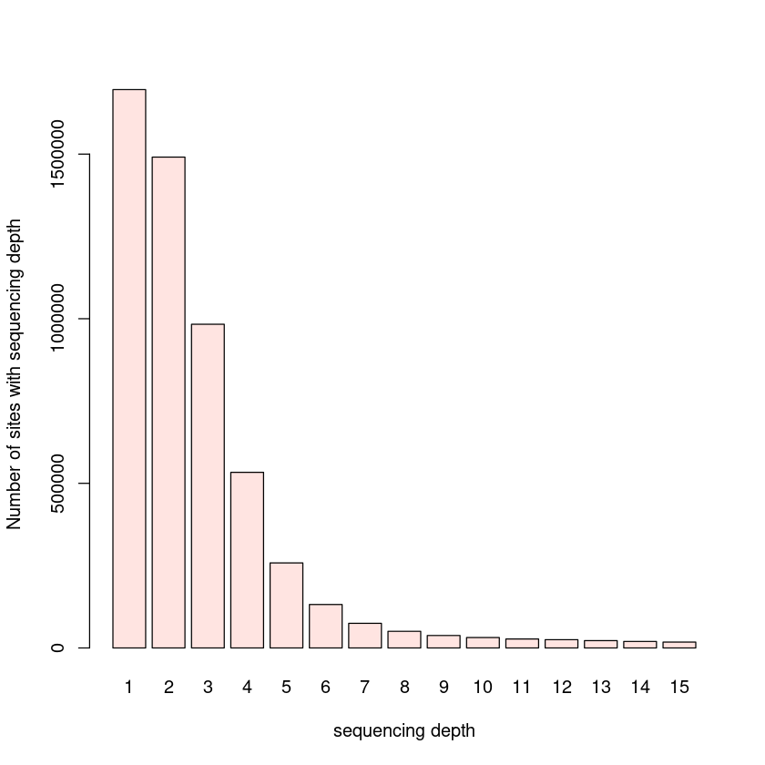

**Questions**

- What is the most common sequencing depth?
- At this depth, how confident would you be calling a heterozygous genotype from a single read?

### Run the cell below to take the quiz

```
# run to start quiz
from jupyterquiz import display_quiz
display_quiz('https://raw.githubusercontent.com/popgenDK/courses/main/current_exercises/ngs/quiz/depth.json')
```

- How do you think the depth will affect genotype and variant calling?

First let's view the mpileup with the reference

```
samtools mpileup -f $REF $SAMPLE.sorted.bam | head -n 20
```

```
[mpileup] 1 samples in 1 input files
chr21	2627371	N	0	*	*
chr21	2627372	N	0	*	*
chr21	2627373	N	0	*	*
chr21	2627374	N	0	*	*
chr21	2627375	N	0	*	*
chr21	2627376	N	0	*	*
chr21	2627377	N	0	*	*
chr21	2627378	N	0	*	*
chr21	2627379	N	0	*	*
chr21	2627380	N	0	*	*
chr21	2627381	N	0	*	*
chr21	2627382	N	0	*	*
chr21	2627383	N	0	*	*
chr21	2627384	N	0	*	*
chr21	2627385	N	0	*	*
chr21	2627386	N	0	*	*
chr21	2627387	N	0	*	*
chr21	2627388	N	0	*	*
chr21	2627389	N	0	*	*
chr21	2627390	N	0	*	*
```

- Can you see the difference compared to not using the reference genome.
- Can you identify a heterozygous site? (e.g. position 9719896)

### Variant calling

[figure not shown]

- Pileup -> variant

```
## remove duplicates
samtools rmdup -s $SAMPLE.sorted.bam $SAMPLE.md.bam

## call variants
bcftools mpileup -Ou -f $REF $SAMPLE.md.bam | bcftools call -mv -Ov -o $SAMPLE.vcf
```

```
Note: none of --samples-file, --ploidy or --ploidy-file given, assuming all sites are diploid
[mpileup] 1 samples in 1 input files
[mpileup] maximum number of reads per input file set to -d 250
```

**Questions**

- The VCF was made from `NA19238.md.bam`, the file with duplicates removed, not from the sorted BAM. Why?
- `bcftools call` was run with `-mv`. What would the file look like without the `-v`?

Let's have a look at the VCF file

```
head -n 50 $SAMPLE.vcf
```

```
##fileformat=VCFv4.2
##FILTER=<ID=PASS,Description="All filters passed">
##bcftoolsVersion=1.13+htslib-1.13+ds
##bcftoolsCommand=mpileup -Ou -f chr21.fa.gz NA19238.md.bam
##reference=file://chr21.fa.gz
##contig=<ID=chr21,length=46944323>
##ALT=<ID=*,Description="Represents allele(s) other than observed.">
##INFO=<ID=INDEL,Number=0,Type=Flag,Description="Indicates that the variant is an INDEL.">
##INFO=<ID=IDV,Number=1,Type=Integer,Description="Maximum number of raw reads supporting an indel">
##INFO=<ID=IMF,Number=1,Type=Float,Description="Maximum fraction of raw reads supporting an indel">
##INFO=<ID=DP,Number=1,Type=Integer,Description="Raw read depth">
##INFO=<ID=VDB,Number=1,Type=Float,Description="Variant Distance Bias for filtering splice-site artefacts in RNA-seq data (bigger is better)",Version="3">
##INFO=<ID=RPBZ,Number=1,Type=Float,Description="Mann-Whitney U-z test of Read Position Bias (closer to 0 is better)">
##INFO=<ID=MQBZ,Number=1,Type=Float,Description="Mann-Whitney U-z test of Mapping Quality Bias (closer to 0 is better)">
##INFO=<ID=BQBZ,Number=1,Type=Float,Description="Mann-Whitney U-z test of Base Quality Bias (closer to 0 is better)">
##INFO=<ID=MQSBZ,Number=1,Type=Float,Description="Mann-Whitney U-z test of Mapping Quality vs Strand Bias (closer to 0 is better)">
##INFO=<ID=SCBZ,Number=1,Type=Float,Description="Mann-Whitney U-z test of Soft-Clip Length Bias (closer to 0 is better)">
##INFO=<ID=FS,Number=1,Type=Float,Description="Phred-scaled p-value using Fisher's exact test to detect strand bias">
##INFO=<ID=SGB,Number=1,Type=Float,Description="Segregation based metric.">
##INFO=<ID=MQ0F,Number=1,Type=Float,Description="Fraction of MQ0 reads (smaller is better)">
##FORMAT=<ID=PL,Number=G,Type=Integer,Description="List of Phred-scaled genotype likelihoods">
##FORMAT=<ID=GT,Number=1,Type=String,Description="Genotype">
##INFO=<ID=AC,Number=A,Type=Integer,Description="Allele count in genotypes for each ALT allele, in the same order as listed">
##INFO=<ID=AN,Number=1,Type=Integer,Description="Total number of alleles in called genotypes">
##INFO=<ID=DP4,Number=4,Type=Integer,Description="Number of high-quality ref-forward , ref-reverse, alt-forward and alt-reverse bases">
##INFO=<ID=MQ,Number=1,Type=Integer,Description="Average mapping quality">
##bcftools_callVersion=1.13+htslib-1.13+ds
##bcftools_callCommand=call -mv -Ov -o NA19238.vcf; Date=Wed Sep 16 19:52:30 2026
#CHROM	POS	ID	REF	ALT	QUAL	FILTER	INFO	FORMAT	bar
chr21	9719793	.	G	T	17.438	.	DP=5;VDB=0.28;SGB=-0.453602;RPBZ=-0.408248;BQBZ=1.22474;SCBZ=0;FS=0;MQ0F=0;AC=1;AN=2;DP4=2,0,1,1;MQ=60	GT:PL	0/1:50,0,63
chr21	9719793	.	gtt	gTtt	25.488	.	INDEL;IDV=2;IMF=0.4;DP=5;VDB=0.026713;SGB=-0.453602;RPBZ=0.296174;MQBZ=0.816497;BQBZ=1.22474;SCBZ=-0.57735;FS=0;MQ0F=0;AC=1;AN=2;DP4=1,1,2,0;MQ=55	GT:PL	0/1:58,0,10
chr21	9719797	.	G	C	79.4149	.	DP=6;VDB=0.114666;SGB=-0.590765;FS=0;MQ0F=0;AC=2;AN=2;DP4=0,0,4,1;MQ=60	GT:PL	1/1:109,15,0
chr21	9719802	.	A	T	3.52994	.	DP=8;VDB=0.38;SGB=-0.453602;RPBZ=-0.591608;BQBZ=-0.195402;SCBZ=-1.28198;FS=0;MQ0F=0;AC=1;AN=2;DP4=4,1,2,0;MQ=60	GT:PL	0/1:35,0,144
chr21	9719804	.	T	C	160.416	.	DP=8;VDB=0.166446;SGB=-0.636426;FS=0;MQ0F=0;AC=2;AN=2;DP4=0,0,6,1;MQ=60	GT:PL	1/1:190,21,0
chr21	9719812	.	T	G	48.0824	.	DP=10;VDB=0.154358;SGB=-0.511536;RPBZ=-0.452635;BQBZ=0.614865;SCBZ=-1.54919;FS=0;MQ0F=0;AC=1;AN=2;DP4=4,1,3,0;MQ=60	GT:PL	0/1:81,0,156
chr21	9719813	.	T	C	14.9832	.	DP=11;VDB=0.38;SGB=-0.453602;RPBZ=0.14762;BQBZ=0.917365;SCBZ=-1.04978;FS=0;MQ0F=0;AC=1;AN=2;DP4=6,1,2,0;MQ=60	GT:PL	0/1:49,0,184
chr21	9719834	.	G	T	58.6867	.	DP=14;VDB=0.23997;SGB=-0.556411;RPBZ=0.0850696;BQBZ=-0.434596;SCBZ=0.506488;FS=0;MQ0F=0;AC=1;AN=2;DP4=6,2,4,0;MQ=60	GT:PL	0/1:92,0,239
chr21	9719864	.	T	C	168.917	.	DP=16;VDB=0.564756;SGB=-0.680642;RPBZ=-1.0835;BQBZ=-1.39637;SCBZ=0.731925;FS=0;MQ0F=0;AC=1;AN=2;DP4=3,0,11,1;MQ=60	GT:PL	0/1:203,0,80
chr21	9719896	.	G	T	85.0814	.	DP=18;VDB=0.4587;SGB=-0.616816;RPBZ=0.705543;BQBZ=-0.0550482;SCBZ=0.282843;FS=0;MQ0F=0;AC=1;AN=2;DP4=9,1,6,0;MQ=60	GT:PL	0/1:118,0,208
chr21	9719903	.	G	C	46.5665	.	DP=19;VDB=0.983626;SGB=-0.511536;RPBZ=0.794566;BQBZ=-0.292085;SCBZ=-0.5;FS=0;MQ0F=0;AC=1;AN=2;DP4=9,3,2,1;MQ=60	GT:PL	0/1:81,0,255
chr21	9719938	.	T	C	161.725	.	DP=28;VDB=0.012598;SGB=-0.616816;RPBZ=0.307105;MQBZ=-1.47196;MQSBZ=0.852803;BQBZ=0;FS=0;MQ0F=0;AC=1;AN=2;DP4=8,5,3,3;MQ=58	GT:PL	0/1:195,0,255
chr21	9719951	.	G	T,C	194.708	.	DP=26;VDB=0.0157933;SGB=-0.688148;RPBZ=0.400176;MQBZ=-0.516398;MQSBZ=0.852803;BQBZ=0.206632;FS=0;MQ0F=0;AC=1,1;AN=2;DP4=3,1,8,7;MQ=58	GT:PL	1/2:255,42,159,141,0,255
chr21	9719952	.	T	A	46.8631	.	DP=30;VDB=0.0320192;SGB=-0.556411;RPBZ=0.70895;MQBZ=-2;MQSBZ=0.816497;BQBZ=-0.535645;FS=0;MQ0F=0;AC=1;AN=2;DP4=10,6,2,2;MQ=59	GT:PL	0/1:82,0,255
chr21	9719956	.	A	T	220.318	.	DP=29;VDB=0.0725163;SGB=-0.662043;RPBZ=0.177725;MQBZ=-1.1547;MQSBZ=0.866025;BQBZ=0.439891;FS=0;MQ0F=0;AC=1;AN=2;DP4=8,4,4,5;MQ=59	GT:PL	0/1:253,0,255
chr21	9719957	.	G	C	3.63398	.	DP=29;VDB=0.38;SGB=-0.453602;RPBZ=0.359542;MQBZ=0.324443;MQSBZ=0.866025;BQBZ=0.691356;FS=0;MQ0F=0;AC=1;AN=2;DP4=11,8,1,1;MQ=59	GT:PL	0/1:38,0,255
chr21	9719964	.	G	T	3.6591	.	DP=31;VDB=0.036923;SGB=-0.511536;RPBZ=1.65882;MQBZ=-2.64575;MQSBZ=0.845154;BQBZ=-0.325992;FS=0;MQ0F=0;AC=1;AN=2;DP4=13,8,1,2;MQ=59	GT:PL	0/1:38,0,255
chr21	9719981	.	A	T	121.721	.	DP=37;VDB=0.837746;SGB=-0.616816;RPBZ=-1.2601;MQBZ=0.522233;MQSBZ=0.866025;BQBZ=-0.695595;FS=0;MQ0F=0;AC=1;AN=2;DP4=12,10,4,2;MQ=59	GT:PL	0/1:156,0,255
chr21	9720007	.	C	G	222.248	.	DP=34;VDB=0.134395;SGB=-0.688148;RPBZ=1.28201;BQBZ=-0.612617;SCBZ=0.774597;FS=0;MQ0F=0;AC=1;AN=2;DP4=4,5,9,6;MQ=60	GT:PL	0/1:255,0,255
chr21	9720018	.	G	T	81.9654	.	DP=30;VDB=0.307124;SGB=-0.662043;RPBZ=0.924241;BQBZ=-0.39522;FS=0;MQ0F=0;AC=1;AN=2;DP4=7,8,5,4;MQ=60	GT:PL	0/1:116,0,255
chr21	9720034	.	C	G	31.8927	.	DP=26;VDB=0.300397;SGB=-0.590765;RPBZ=0.92582;BQBZ=-2.61215;FS=0;MQ0F=0;AC=1;AN=2;DP4=8,6,3,2;MQ=60	GT:PL	0/1:67,0,255
```

The header of the VCF contains meta information about what it in the file. In the body of the file

- Identify the position, the reference allele and the alternative allele of the file.
- Identify the depth of each position
- Find a tri-allelic site. Do you believe that it is truly triallelic?
- How many sites are called as variable?

# Bonus exercise (Only do this part if you have finished the rest)

## Bonus exercise 1 - duplicated reads using Picardtools

bwa actually fills in the mate information, but not all aligners do that, so we can run picard tools to fill in the mate information and sort the file according to position. We will output the file in the binary version of SAM which is BAM

[output not shown]

```
java -jar $PICARD FixMateInformation INPUT=$SAMPLE.sam \
OUTPUT=id.fixmate.srt.bam SORT_ORDER=coordinate
```

[output not shown]

**Question**

- Picard was given the SAM file and wrote a BAM file sorted by coordinate. Which two things did it change in one step?

View the header of the BAM file

```
samtools view -H id.fixmate.srt.bam
```

```
@HD	VN:1.6	SO:coordinate
@SQ	SN:chr21	LN:46944323
@RG	ID:foo	SM:bar	LB:library1
@PG	ID:bwa	PN:bwa	VN:0.7.17-r1188	CL:bwa mem -R @RG\tID:foo\tSM:bar\tLB:library1 -t 5 chr21.fa.gz NA19238.YRI.low_coverage.chr21_1.fq.gz NA19238.YRI.low_coverage.chr21_2.fq.gz
@PG	ID:samtools	PN:samtools	PP:bwa	VN:1.13	CL:samtools view -H id.fixmate.srt.bam
```

**Question**

- Which lines describe the reference sequences, and which describe the programs that have touched the file?

picard didn't update the PG flag, so let us update the header information so that we have documented how we modified the file.

```
(samtools view -H id.fixmate.srt.bam;echo -e "@PG\tID:fixmate\tPN:fixmate\tVN:2.60\tCL:stuff" ) >newhd
samtools reheader newhd id.fixmate.srt.bam > id.fixmate.srt2.bam
```

**Question**

- What was added to the header by the command above, and why is it good practice to record it?
- Validate that the header in file id.fixmate.srt2.bam has been updated

```
samtools view -H id.fixmate.srt2.bam
```

```
@HD	VN:1.6	SO:coordinate
@SQ	SN:chr21	LN:46944323
@RG	ID:foo	SM:bar	LB:library1
@PG	ID:bwa	PN:bwa	VN:0.7.17-r1188	CL:bwa mem -R @RG\tID:foo\tSM:bar\tLB:library1 -t 5 chr21.fa.gz NA19238.YRI.low_coverage.chr21_1.fq.gz NA19238.YRI.low_coverage.chr21_2.fq.gz
@PG	ID:samtools	PN:samtools	PP:bwa	VN:1.13	CL:samtools view -H id.fixmate.srt.bam
@PG	ID:fixmate	PN:fixmate	VN:2.60	CL:stuff
@PG	ID:samtools.1	PN:samtools	PP:samtools	VN:1.13	CL:samtools reheader newhd id.fixmate.srt.bam
@PG	ID:samtools.2	PN:samtools	PP:samtools.1	VN:1.13	CL:samtools view -H id.fixmate.srt2.bam
```

**Question**

- Compare this header with the one you printed before. Which line is new?

Now mark duplicates using picard

```
java -jar $PICARD MarkDuplicates I=id.fixmate.srt2.bam \
O=id.fixmate.srt.md.bam  M=metrics;
```

[output not shown]

- Did picard update the PG flag of the header?
- Did picard update anything else in the header?

NB you can view the header of a bamfile using 'samtools view -H'

```
samtools view -H id.fixmate.srt.md.bam
```

```
@HD	VN:1.6	SO:coordinate
@SQ	SN:chr21	LN:46944323
@RG	ID:foo	SM:bar	LB:library1
@PG	ID:bwa	PN:bwa	VN:0.7.17-r1188	CL:bwa mem -R @RG\tID:foo\tSM:bar\tLB:library1 -t 5 chr21.fa.gz NA19238.YRI.low_coverage.chr21_1.fq.gz NA19238.YRI.low_coverage.chr21_2.fq.gz
@PG	ID:samtools	PN:samtools	PP:bwa	VN:1.13	CL:samtools view -H id.fixmate.srt.bam
@PG	ID:fixmate	PN:fixmate	VN:2.60	CL:stuff
@PG	ID:samtools.1	PN:samtools	PP:samtools	VN:1.13	CL:samtools reheader newhd id.fixmate.srt.bam
@PG	ID:MarkDuplicates	VN:2.19.0-SNAPSHOT	CL:MarkDuplicates INPUT=[id.fixmate.srt2.bam] OUTPUT=id.fixmate.srt.md.bam METRICS_FILE=metrics    MAX_SEQUENCES_FOR_DISK_READ_ENDS_MAP=50000 MAX_FILE_HANDLES_FOR_READ_ENDS_MAP=8000 SORTING_COLLECTION_SIZE_RATIO=0.25 TAG_DUPLICATE_SET_MEMBERS=false REMOVE_SEQ…
@PG	ID:samtools.2	PN:samtools	PP:samtools.1	VN:1.13	CL:samtools view -H id.fixmate.srt.md.bam
```

## Bonus exercise 2 - clean you bam files using the FLAGS column

The second column in the SAM format is the very important FLAG. This will tell you about the state of the paired-end mapping, QC duplicates etc.

Using the samtools -F/-f you can discard/include flags that fulfill certain patterns. See http://broadinstitute.github.io/picard/explain-flags.html .

1. How many reads have we marked as duplicate in the final file.
2. How many properly mapped read pairs do we have? (Where both reads map to the same chr etc).
3. How many mapped reads do we have ?
4. How many unmapped reads do we have ?
5. Find the distribution of the RNAMES of the unmapped reads!?

Run the following command one at a time by uncommenting them

```
#samtools view -f 1024 id.fixmate.srt.md.bam|wc -l
#samtools view -f 2 id.fixmate.srt.md.bam|wc -l
#samtools view -F 4 id.fixmate.srt.md.bam|wc -l
#samtools view -f 4 id.fixmate.srt.md.bam|wc -l
# samtools view -f 4 id.fixmate.srt.md.bam|cut -f3|sort -n |uniq -c
```

**Questions**

- Uncomment the lines above one at a time and run them. How many reads are unmapped?
- How many are marked as duplicates?
- `-f 4` and `-F 4` give different counts. What is the relationship between the two numbers?

Compare with "samtools flagstat" command

```
samtools flagstat id.fixmate.srt.md.bam
```

```
345791 + 0 in total (QC-passed reads + QC-failed reads)
343760 + 0 primary
0 + 0 secondary
2031 + 0 supplementary
5777 + 0 duplicates
5777 + 0 primary duplicates
280770 + 0 mapped (81.20% : N/A)
278739 + 0 primary mapped (81.09% : N/A)
343760 + 0 paired in sequencing
171880 + 0 read1
171880 + 0 read2
269744 + 0 properly paired (78.47% : N/A)
275806 + 0 with itself and mate mapped
2933 + 0 singletons (0.85% : N/A)
0 + 0 with mate mapped to a different chr
0 + 0 with mate mapped to a different chr (mapQ>=5)
```

**Questions**

- What fraction of the reads mapped?
- What fraction were properly paired?
- Do the numbers agree with what you counted by hand with `-f` and `-F`?

### Run the cell below to take the quiz

```
# run to start quiz
from jupyterquiz import display_quiz
display_quiz('https://raw.githubusercontent.com/popgenDK/courses/main/current_exercises/ngs/quiz/flags.json')
```

Make a new bamfile, where you keep only the reads where both ends map, and filter out those with a mapping quality below 10, and removing duplicates

```
samtools view -f 2 -F 1024 id.fixmate.srt.md.bam -q 10 >new.bam
```

**Questions**

- How many reads are left in `new.bam` compared with the file you started from?
- Each of the three filters (`-f 2`, `-F 1024`, `-q 10`) removes a different kind of read. Which one removed the most?

**You have now been through the whole pipeline: FASTQ → SAM → BAM → VCF.** For each of the three file formats, try to say in one sentence what it stores and what one line in it represents.